# Solution - Energy Interactions in Photovoltaic Solar Water Pumping

Hernan Figueroa and Vijay Modi, Sustainable Engineering Lab

1. Photovoltaic Energy Conversion (STC conditions): Photovoltaic cells convert radiant solar energy to electrical energy. This conversion is primarily dependent on solar irradiance and temperature. A Current vs Voltage curve (IV curve) for a solar PV generator is given by: $V_g = -I_g*R_{sg} + \frac{1}{q/\eta_g kT} ln(\frac{I_{0g}+I_{phg}-I_{g}}{I_{0g}})$ $V_g$ is the generator voltage, $I_{g}$ is the generator current, $R_{sg}$ is the generator series resistance, $T$ is temperature and $\eta_g$ is the ideality factor, $I_{0g}$ is the generator reverse saturation current and $I_{phg}$ is the photo current proportional to the isolation. The constants $q=1.6E-19$ and $k=1.38E-23$ We use a generator with an array of 4 solar modules in series with the following characteristics: $V_{oc} = 45.1V \quad I_{ph} ~ I_{sc} = 8.8A \quad R_s=0.2ohm \quad \eta=99.5$ Parameters are given under standard test conditions (STC) $T = 25°C = 298°K$ and isolation $Er = 1000W/m^2$. NOTE: $V_{oc}$ is the voltage at open circuit ($I_g=0$) and can be used to calculate $I_{0g}$. For $N_s$ modules in series, $R_{sg}=N_s*R_s$, $V_{ocg}=V_{oc}*N_s$ and $\eta_g=\eta*N_s$

```r
T0 <- 25+273 # Temperature in Kelvin
Ns=4
Rs=0.2
Isc.T0 = 8.8
Voc.T0 <- 45.1
eta <- 99.5
Dg.T0 <- 1.6E-19/(1.38E-23*eta)/T0/Ns
Vocg.T0 <- Ns*Voc.T0
Iphg.T0 <- Isc.T0
I0g.T0 <- Iphg.T0/exp(Vocg.T0*Dg.T0)
Rsg <- Rs*Ns
Im.axis <- seq(0,Iphg.T0,by=0.005)
Vg.axis <- -Im.axis*Rsg + 1/(Dg.T0)*log((Iphg.T0-Im.axis+I0g.T0)/I0g.T0)
Power <- Im.axis*Vg.axis
Power.ind <- which(Power==max(Power))
```

Plot the I-V curve under STC conditions.

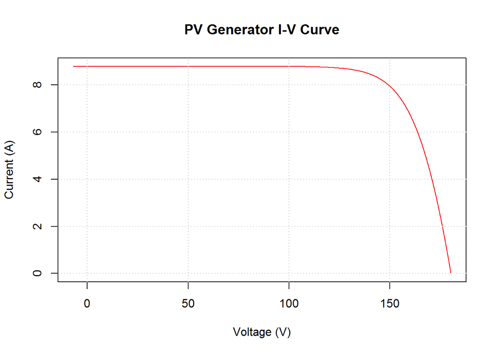

Plot the power curve for this generator.

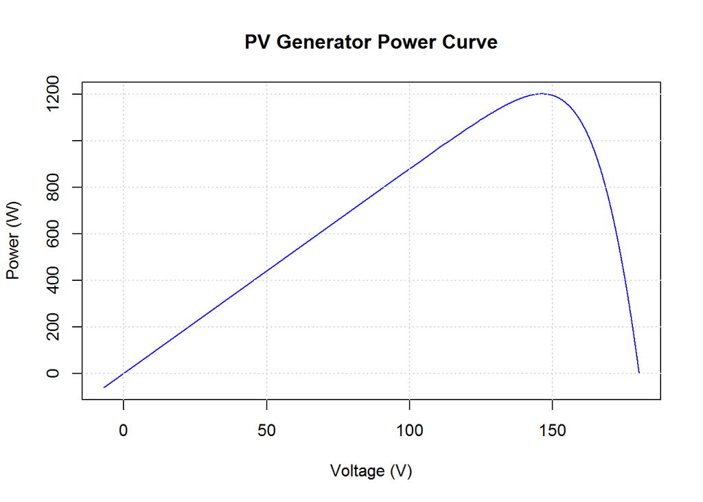

Indicate the maximum power value and the ($V_g$,$I_g$) point at maximum power for this generator.

```
## [1] 146.3676
```

```
## [1] 8.2
```

```
## [1] 1200.215
```

2. Electric to mechanical energy conversion The equations for a single pole DC motor at steady state are: $\omega_m = \frac{V_m - I_m*R_a}{C_e}$ $\tau_m = I_m*C_e-\nu_m*\omega_m$ Where $V_m$ is the voltage applied to the motor, $I_m$ is the current developed at the motor, $R_a$ is the motor resistance, $C_e$ is a motor constant that takes into account materials and design of the motor rotor and stator, $\nu_m$ is the motor viscous friction constant. This motor has constant armature self inductance and negligible iron losses. We use a motor with $R_a$=2.8 ohm, $C_e$=0.27 V/rad and $\nu_m=7.96$E-4 connected directly with the solar array described in 1. NOTE: When the motor is connected directly to the array, $I_m=I_g$ and $V_m=V_g$.

Plot the Speed vs Torque curve for this motor. Consider only the range in which $\omega_m>0$ and $\tau_m >0$

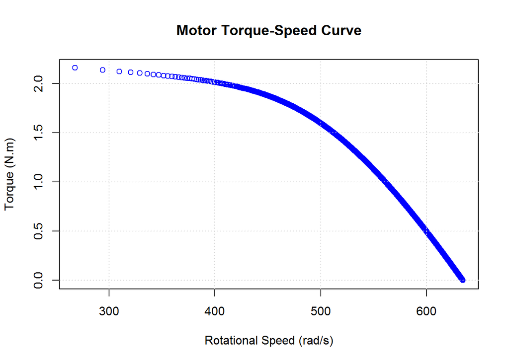

Plot the electrical power input and the mechanical power for this motor for the acceptable range.

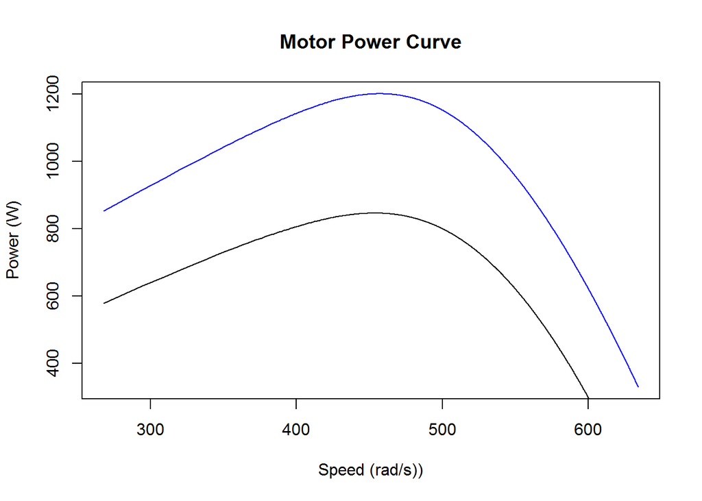

```
## [1] 845.8693
```

Plot the power efficiency for this motor.

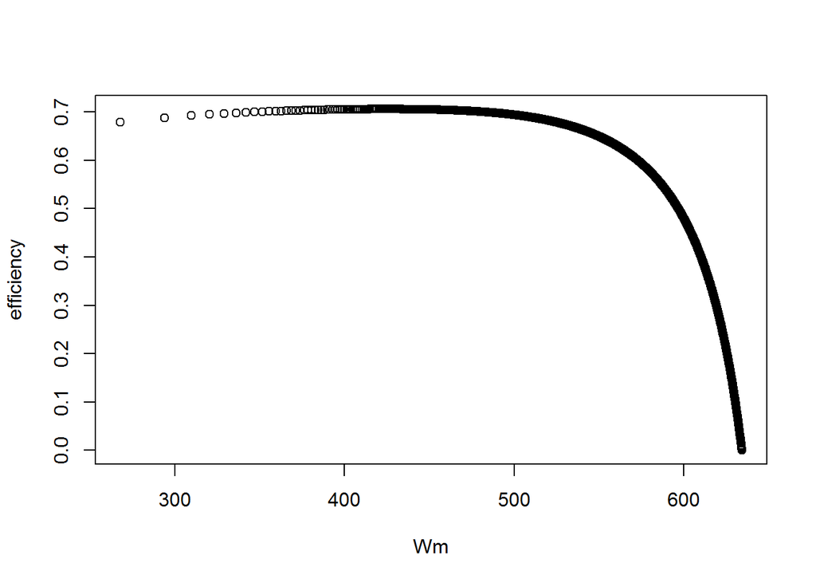

Discuss potential losses.

3. Conversion to water kinetic energy When the DC motor is connected to a centrifugal pump, the motor mechanical rotation will accelerate water inside impellers and convert the mechanical rotational energy from the motor to kinetic energy in the water. A torque vs speed equation for a centrifugal pump is close to a quadratic formula: $T_{lp} = K_p*\omega_p^{2}$ Where $K$ is a pump constant. We use a pump constant $K_p$=1.27E-5. Find the operating point for this pump load connected to the motor discussed in 3. NOTE: Operating points are usually found intersecting curves. The folowing affinity laws govern the conversion from pump rotational speed to water flow and head.

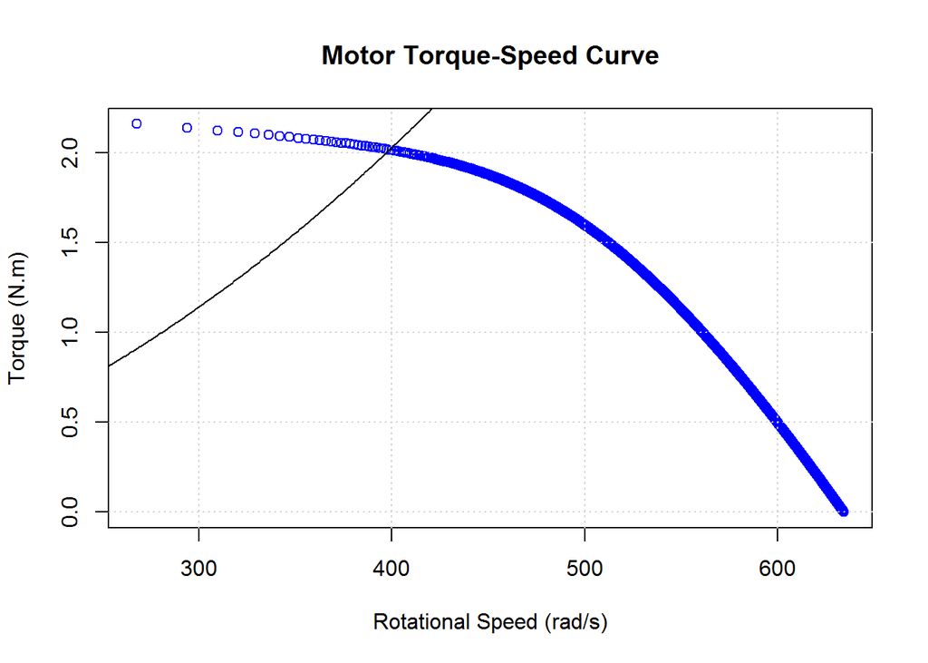